# Modeling Interventions

We’d like to be able to model interventions (both past and proposed) with the standard model. How would that work? Let’s consider Gilkerson et al. (2017), in which 72 parents of typically developing children aged 9 to 21 months were assigned to immediate- or delayed-treatment (control) conditions. During treatment, parents were recorded 10 times over a 3-month period while engaging in a web-based intervention offering strategies for increasing talk and interaction. During a 9-month follow-up, parents completed additional recordings and language assessments. Overall, no differences were found in language behaviors between immediate-treatment versus delayed-treatment groups. However, parents who were at first below-average on automated language measures showed significant postintervention increases which held longitudinally, and children showed significant elevations in language ability. Problem: Gilkerson 2017 only reports standardized scores (mean = 100 and SD = 15) for AWC (median split: bottom half M=84.09, upper half M=116.01), which are calculated from the original LENA norms (Gilkerson & Richards, 2008), where they report overall M=12,297 (SD=6462) per 12-hour session (so 1025 words/hour).

| age_mos | AWC_mean | AWC_sd |
| --- | --- | --- |
| 2-17 | 14484 | 6022 |
| 18-24 | 11768 | 4159 |
| 25+ | 12928 | 4342 |

```
## # A tibble: 5 x 8
##   study                AWC_mean AWC_sd CVC_mean CVC_sd     N AWChr_mean AWChr_sd
##   <chr>                   <dbl>  <dbl>    <dbl>  <dbl> <dbl>      <dbl>    <dbl>
## 1 Gilkerson et al. 20…    12709   4274     1817    787    72      1059.     356.
## 2 Greenwood et al. 20…    13142   5562     1714    850    30      1095.     464.
## 3 Soderstrom & Witteb…    10125   4890     1744   1058    11       844.     408.
## 4 Zimmerman et al. 20…    12800   4400       NA     NA   275      1067.     367.
## 5 Bergelson et al. 20…    16510   8718     1432    764    59      1376.     726.
```

Let’s use the hourly rates from individual children from Sperry et al. (2018), Hart & Risley (1995), Soderstrom & Wittebolle (2013), and Weisleder & Fernald (2013) to estimate the parameters of hourly input rate distributions for both child-directed speech (CDS) and all adult speech.

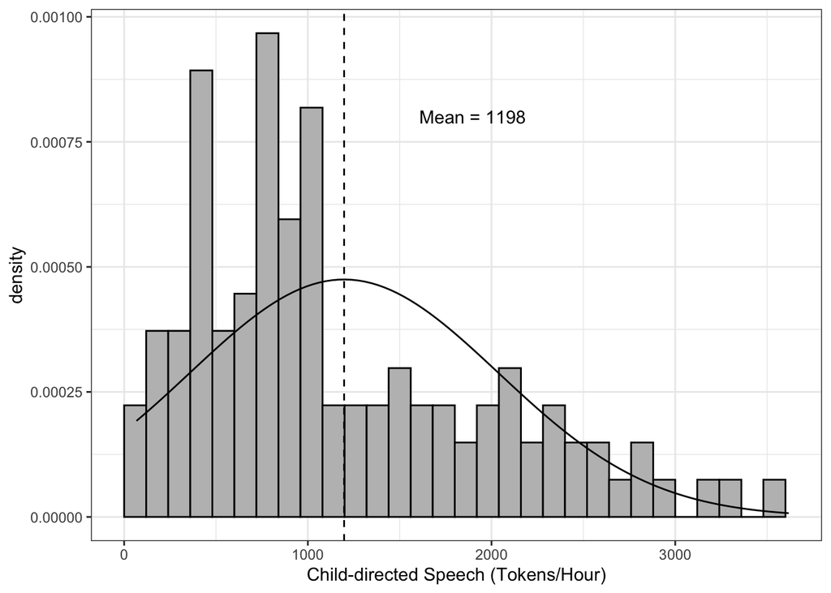

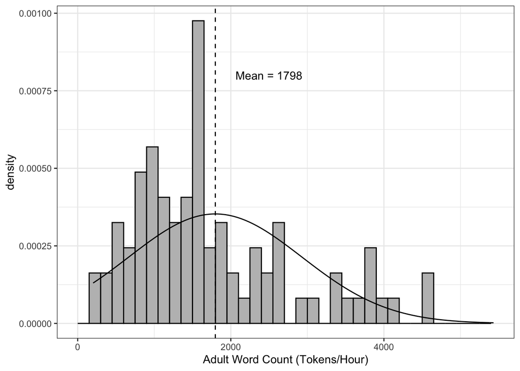

Based on data from 113 children, the mean number of child-directed tokens heard per hour is 1198 (sd=840). Using data from 83 children, the mean number of all adult tokens heard per hour is 1798 (sd=1130).

## References

Gilkerson, J., Richards, J. A., & Topping, K. (2017). Evaluation of a lena-based online intervention for parents of young children. Journal of Early Intervention, 1053815117718490.

Greenwood, C. R., Thiemann-Bourque, K., Walker, D., Buzhardt, J., & Gilkerson, J. (2011). Assessing children’s home language environments using automatic speech recognition technology. Communication Disorders Quarterly, 32(2), 83-92.

Soderstrom, M., & Wittebolle, K. (2013). When do caregivers talk? the influences of activity and time of day on caregiver speech and child vocalizations in two childcare environments. PloS one, 8(11), e80646.

Weisleder, A., & Fernald, A. (2013). Talking to Children Matters: Early Language Experience Strengthens Processing and Builds Vocabulary. Psychological Science, 24(11), 2143–2152.

Zimmerman, F. J., Gilkerson, J., Richards, J. A., Christakis, D. A., Xu, D., Gray, S., & Yapanel, U. (2009). Teaching by listening: The importance of adult-child conversations to language development. Pediatrics, 124(1), 342–349.